# Homework 1

Yusuf Ulucoban - Eda Kocakarın

02 04 2022

```r
library(data.table)
library(ggplot2)
library(lattice)
library(caTools)
library(rpart)
library(rpart.plot)
library(tree)
library(caret)
library(Metrics)
library(MASS)
```

## Question1

Consider the dataset given in the file “Financialdistress-cat.csv”. The output attribute to be predicted is the Financial.Distress attribute, which is zero if the company is in a healthy condition, one otherwise. Use a seed value of 500 whereever you need a seed.

### Question 1a

1. Partition the dataset into training and test sets where 75% of goes into the training set and 25% goes into the test set. What is the percentage of companies in distress in the overall, training, and test sets?

Since the importance is with predicting the Financial.Distress class correctly and there may not be many observations of this class, it is a good idea to keep the percentage of Financial.Distress similar in both sets. The data can be splitted into training and test sets by,

```r
financial <- read.csv("C:/Users/Yuluc/OneDrive/Desktop/FinancialDistress-Cat.csv")
financial$Financial.Distress = as.factor(financial$Financial.Distress)
split = sample.split(financial$Financial.Distress, SplitRatio = 0.75)
train = subset(financial, split == TRUE)
test = subset(financial, split == FALSE)
```

Percantages can be found as,

```r
mean(as.numeric(train$Financial.Distress) - 1) * 100
```

```
## [1] 6.862745
```

```r
mean(as.numeric(test$Financial.Distress) - 1) * 100
```

```
## [1] 6.862745
```

```r
mean(as.numeric(financial$Financial.Distress) - 1) * 100
```

```
## [1] 6.862745
```

### Question 1b

2. Using the rpart package and training set, determine the best size of the best tree in terms of cross validation error. How many leaf nodes do exist in the tree?

By using the rpart function, the tree is produced. First, the index is found. Then by increasing the nsplit by 1. Size is found as,

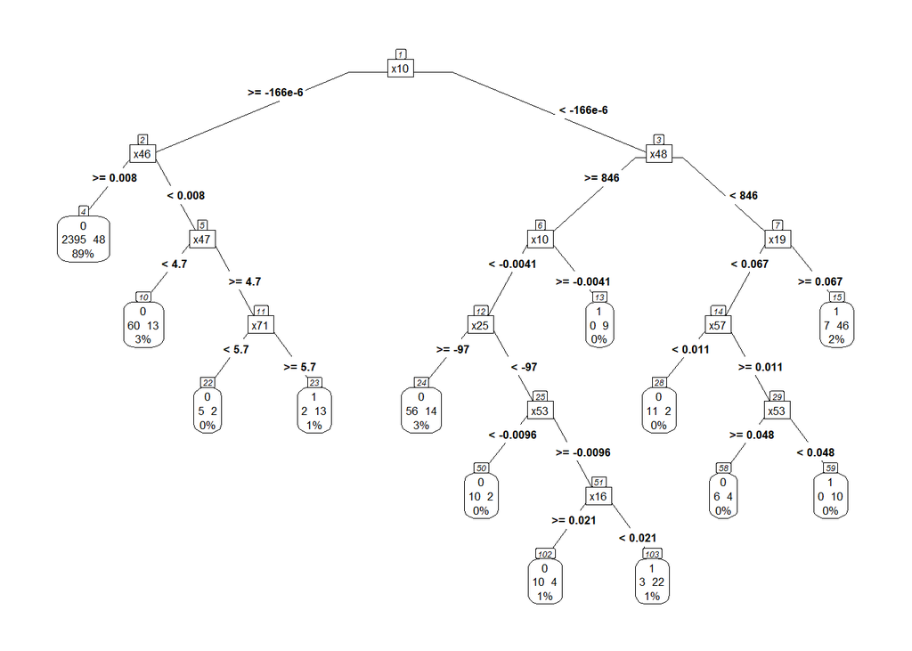

```r
#producing a tree
bt=rpart(Financial.Distress~.,data=train)
prp(bt,type=5,extra=101,nn=TRUE,tweak=1)
```

```r
#finding optimal tree by observing errors and sizes
printcp(bt)
```

```
##
## Classification tree:
## rpart(formula = Financial.Distress ~ ., data = train)
##
## Variables actually used in tree construction:
##  [1] x10 x16 x19 x25 x46 x47 x48 x53 x57 x71
##
## Root node error: 189/2754 = 0.068627
##
## n= 2754
##
##         CP nsplit rel error  xerror     xstd
## 1 0.100529      0   1.00000 1.00000 0.070199
## 2 0.047619      2   0.79894 0.88360 0.066269
## 3 0.034392      3   0.75132 0.86772 0.065709
## 4 0.031746      5   0.68254 0.88889 0.066455
## 5 0.023810      6   0.65079 0.88360 0.066269
## 6 0.021164      8   0.60317 0.87831 0.066083
## 7 0.015873     10   0.56085 0.85714 0.065333
## 8 0.010582     11   0.54497 0.89418 0.066639
## 9 0.010000     12   0.53439 0.90476 0.067006
```

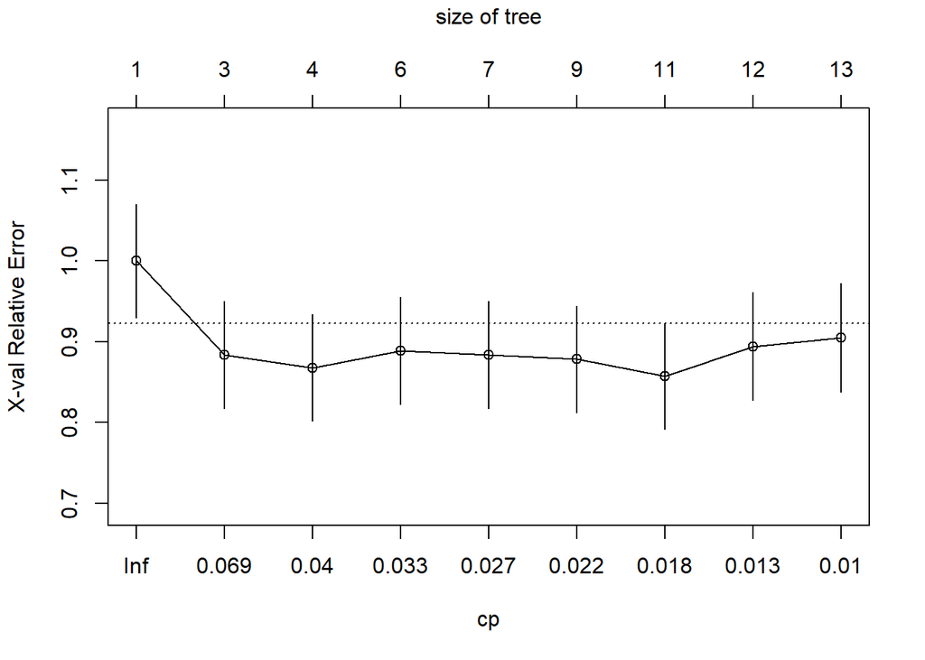

```r
plotcp(bt)
```

```r
print(bt$cptable)
```

```
##           CP nsplit rel error    xerror       xstd
## 1 0.10052910      0 1.0000000 1.0000000 0.07019898
## 2 0.04761905      2 0.7989418 0.8835979 0.06626934
## 3 0.03439153      3 0.7513228 0.8677249 0.06570948
## 4 0.03174603      5 0.6825397 0.8888889 0.06645461
## 5 0.02380952      6 0.6507937 0.8835979 0.06626934
## 6 0.02116402      8 0.6031746 0.8783069 0.06608340
## 7 0.01587302     10 0.5608466 0.8571429 0.06533279
## 8 0.01058201     11 0.5449735 0.8941799 0.06663921
## 9 0.01000000     12 0.5343915 0.9047619 0.06700643
```

```r
# Retrieve optimal cp value based on cross-validated error
opt_index=which.min(bt$cptable[, "xerror"])
opt_index
```

```
## 7
## 7
```

```r
opt_index=which.min(unname(bt$cptable[, "xerror"]))
opt_index
```

```
## [1] 7
```

```r
cp_opt=bt$cptable[opt_index, "CP"]
cp_opt
```

```
## [1] 0.01587302
```

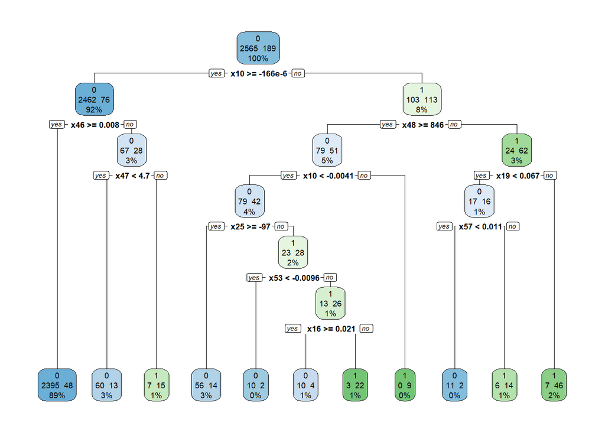

```r
# Prune the model (to optimized cp value)
bt_opt=prune.rpart(tree = bt,cp = cp_opt)
# Plot the optimized model
rpart.plot(x = bt_opt, yesno = 2, type = 2, extra = 101)
```

```r
#of leaf nodes:
bt_opt$cptable[opt_index,"nsplit"] + 1
```

```
## [1] 11
```

### Question 1c

3. Make predictions in the test set and report the error rate, sensitivity, specificity, and precision using the confusionMatrix function of the caret package.

Predictions are made, and also a confusion matrix is illustrated below,

```r
## test kumesindeki satirlar icin tahmin yapma, tahminler 0 veya 1
preds = predict(bt_opt, test, type="c")
table(test$Financial.Distress, preds)
```

```
##    preds
##       0   1
##   0 837  18
##   1  41  22
```

```r
confusionMatrix(test$Financial.Distress, preds)
```

```
## Confusion Matrix and Statistics
##
##           Reference
## Prediction   0   1
##          0 837  18
##          1  41  22
##
##                Accuracy : 0.9357
##                  95% CI : (0.9179, 0.9507)
##     No Information Rate : 0.9564
##     P-Value [Acc > NIR] : 0.998515
##
##                   Kappa : 0.3949
##
##  Mcnemar's Test P-Value : 0.004181
##
##             Sensitivity : 0.9533
##             Specificity : 0.5500
##          Pos Pred Value : 0.9789
##          Neg Pred Value : 0.3492
##              Prevalence : 0.9564
##          Detection Rate : 0.9118
##    Detection Prevalence : 0.9314
##       Balanced Accuracy : 0.7517
##
##        'Positive' Class : 0
##
```

### Question 1d

4. Using the tree package find the size of the tree which makes the cost complexity (measured by the deviance in the tree package) the smallest? How many leaf nodes does it have?

```r
#largest possible tree is found by setting ratio of deviance to 0 and permitting for minimum possible size and cut values
treelarge = tree(Financial.Distress~., train, mindev=0, minsize=2, mincut=1)

#number of leaf nodes can be checked in some ways
summary(treelarge)
```

```
##
## Classification tree:
## tree(formula = Financial.Distress ~ ., data = train, mindev = 0,
##     minsize = 2, mincut = 1)
## Variables actually used in tree construction:
##  [1] "x36"     "x9"      "x24"     "x57"     "x10"     "x25"     "x42"
##  [8] "x18"     "x27"     "x11"     "x12"     "x19"     "x5"      "x1"
## [15] "x33"     "x83"     "x41"     "x44"     "Company" "x58"     "x3"
## [22] "x56"     "x69"     "x23"     "x6"      "x38"     "x21"     "x55"
## [29] "x82"     "x80"     "x4"      "x72"     "x2"      "x22"     "x46"
## [36] "x15"     "x29"     "x20"     "x51"     "x17"     "x39"     "x62"
## [43] "x8"      "Time"    "x32"     "x37"     "x68"     "x66"     "x31"
## [50] "x71"     "x28"
## Number of terminal nodes:  91
## Residual mean deviance:  0 = 0 / 2663
## Misclassification error rate: 0 = 0 / 2754
```

```r
#this also works
sum(treelarge$frame$var == "<leaf>")
```

```
## [1] 91
```

[figure not shown]

```r
#tree can be plotted
plot(treelarge, col="blue")
text(treelarge, cex=0.7, use.n=TRUE)
```

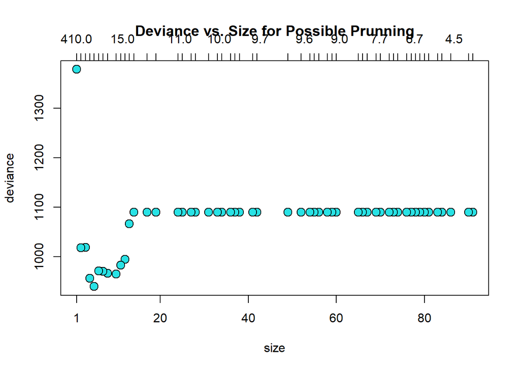

```r
cctree = cv.tree(treelarge,K=10)

plot(cctree, pch=21, bg=5, type="p", cex=1.5, main="Deviance vs. Size for Possible Prunning")
```

```r
#minimum deviation is found
mindev = min(cctree$dev)
#trees with min deviation is selected
list = data.table(Size = cctree$size, Dev = cctree$dev)
#smallest tree from these trees is selected
best_size = min(list[Dev == mindev, Size])
best_size
```

```
## [1] 5
```

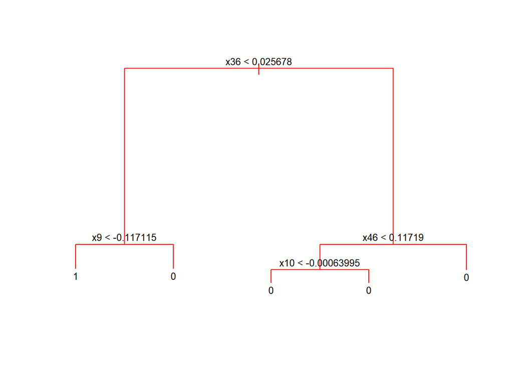

```r
#tree is prunned into best size as optimumtree
optimumtree = prune.tree(treelarge, best=best_size)

#optimumtree is plotted
plot(optimumtree, col="red")
text(optimumtree, cex=0.8)
```

### Question 1e

5. Make predictions in the test set and report the error rate, sensitivity, specificity, and precision using the confusionMatrix function of the caret package. Compare the result with part (c).

```r
#Predictions are made with optimumtree
opt_preds2 = predict(optimumtree, test,type="class")

#Confusion matrix
confusionMatrix(test$Financial.Distress, opt_preds2)
```

```
## Confusion Matrix and Statistics
##
##           Reference
## Prediction   0   1
##          0 847   8
##          1  38  25
##
##                Accuracy : 0.9499
##                  95% CI : (0.9337, 0.9631)
##     No Information Rate : 0.9641
##     P-Value [Acc > NIR] : 0.9888
##
##                   Kappa : 0.4971
##
##  Mcnemar's Test P-Value : 1.904e-05
##
##             Sensitivity : 0.9571
##             Specificity : 0.7576
##          Pos Pred Value : 0.9906
##          Neg Pred Value : 0.3968
##              Prevalence : 0.9641
##          Detection Rate : 0.9227
##    Detection Prevalence : 0.9314
##       Balanced Accuracy : 0.8573
##
##        'Positive' Class : 0
##
```

From results, it is observed that accuracy, sensitivity and specificity are different for each random split. When the process is started again, the numbers may change and the better one differs.  
The sensitivity (otherwise known as the true positive rate) is the proportion of successful extubations that are correctly classified as such, while the specificity (otherwise known as the true negative rate) is the proportion of unsuccessful extubations that are correctly classified as such.

## Question2

Consider the dataset given in the file “ToyotaCorolla.csv”. The output attribute to be predicted is the Price attribute. Use a seed value of 500 whereever you need a seed.

```r
toyota =read.csv("C:/Users/Yuluc/OneDrive/Desktop/ToyotaCorolla.csv")
```

### Question 2a

1. Partition the dataset into training and test sets where 80% of goes into the training set and 20% goes into the test set.

```r
split_toyota = sample.split(toyota$Price, SplitRatio = 0.8)
train_toyota = subset(toyota, split_toyota  == TRUE)
test_toyota = subset(toyota, split_toyota  == FALSE)
```

### Question 2b

2. Using the rpart package and training set, determine the best size of the best tree in terms of cross validation error. How many leaf nodes do exist in the tree?

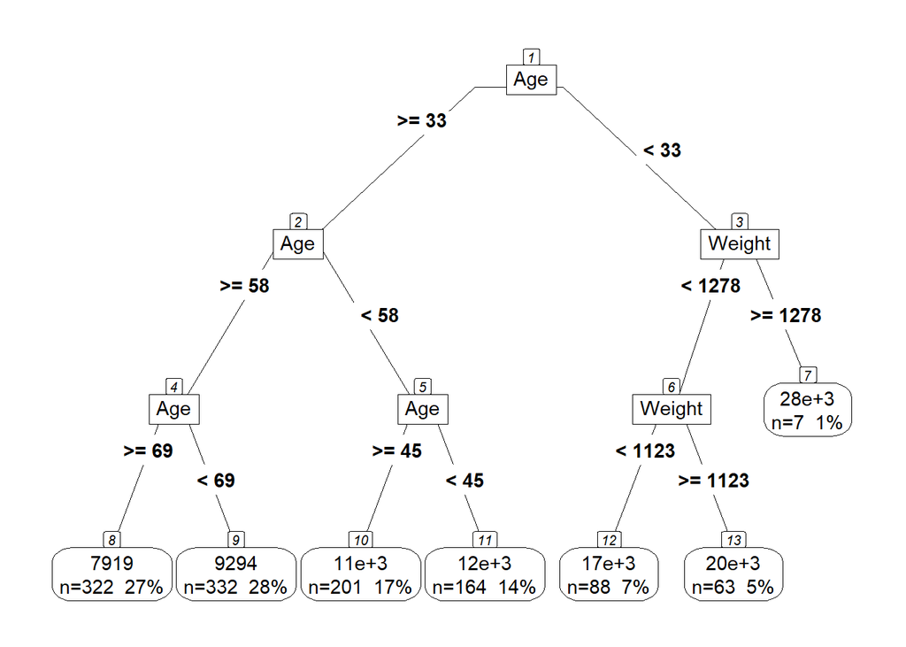

```r
# agaci olusturma
btoyota=rpart(Price~.,data=train_toyota)
prp(btoyota,type=5,extra=101,nn=TRUE,tweak=1)
```

```r
#best tree
printcp(btoyota)
```

```
##
## Regression tree:
## rpart(formula = Price ~ ., data = train_toyota)
##
## Variables actually used in tree construction:
## [1] Age    Weight
##
## Root node error: 1.62e+10/1177 = 13763705
##
## n= 1177
##
##         CP nsplit rel error  xerror     xstd
## 1 0.660650      0   1.00000 1.00160 0.070250
## 2 0.106528      1   0.33935 0.35246 0.024849
## 3 0.037351      2   0.23282 0.24958 0.023129
## 4 0.019085      3   0.19547 0.22168 0.014870
## 5 0.016987      4   0.17639 0.20199 0.015015
## 6 0.015560      5   0.15940 0.19640 0.014641
## 7 0.010000      6   0.14384 0.18161 0.014402
```

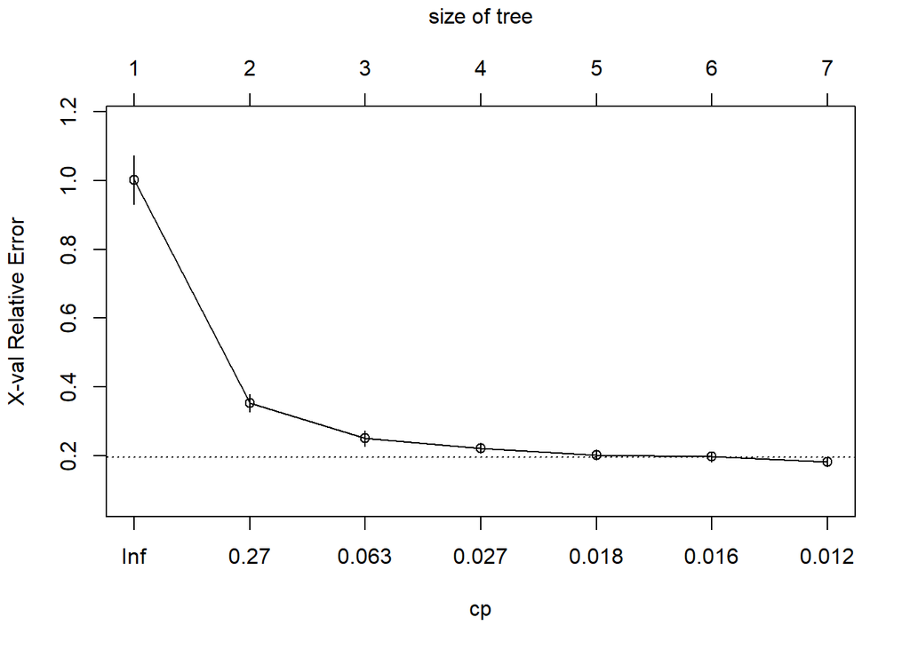

```r
plotcp(btoyota)
```

```r
print(btoyota$cptable)
```

```
##           CP nsplit rel error    xerror       xstd
## 1 0.66064989      0 1.0000000 1.0016000 0.07024959
## 2 0.10652800      1 0.3393501 0.3524625 0.02484923
## 3 0.03735070      2 0.2328221 0.2495777 0.02312894
## 4 0.01908478      3 0.1954714 0.2216833 0.01486966
## 5 0.01698677      4 0.1763866 0.2019915 0.01501544
## 6 0.01555992      5 0.1593999 0.1963986 0.01464147
## 7 0.01000000      6 0.1438399 0.1816117 0.01440250
```

```r
# Retrieve optimal cp value based on cross-validated error
opt_index_toyota=which.min(btoyota$cptable[, "xerror"])
opt_index_toyota
```

```
## 7
## 7
```

```r
opt_index_toyota=which.min(unname(btoyota$cptable[, "xerror"]))
opt_index_toyota
```

```
## [1] 7
```

```r
cp_opt_toyota=btoyota$cptable[opt_index_toyota, "CP"]
cp_opt_toyota
```

```
## [1] 0.01
```

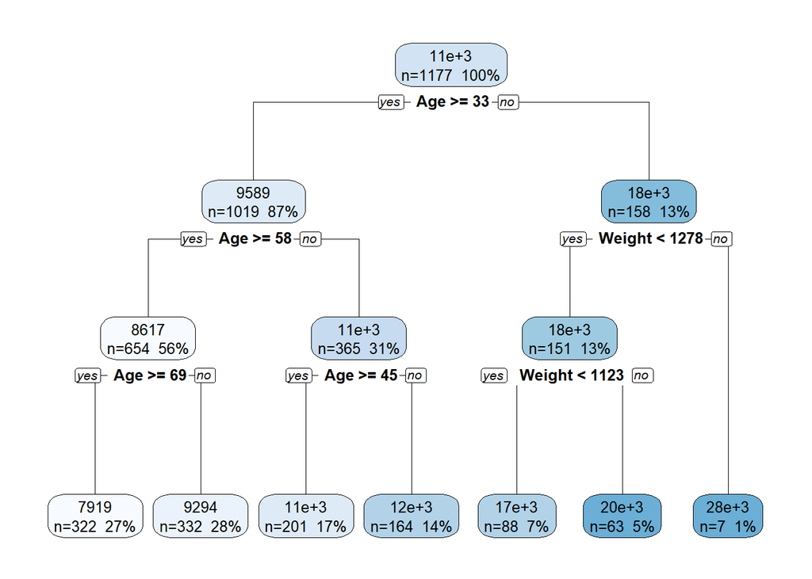

```r
# Prune the model (to optimized cp value)
bt_opt_toyota=prune.rpart(tree = btoyota,cp = cp_opt_toyota)
# Plot the optimized model
rpart.plot(x = bt_opt_toyota, yesno = 2, type = 2, extra = 101)
```

```r
#of leaf nodes:
bt_opt_toyota$cptable[opt_index_toyota,"nsplit"] + 1
```

```
## [1] 7
```

### Question 2c

3. Make predictions in the test set and report the root mean square error rate and mean absolute error using the functions in the Metrics package.

```r
## 10-fold CV for 5 times
ctrl = trainControl(method='repeatedcv',number=10,repeats=5)
fit=train(Price~., data=train_toyota, method = "rpart", metric="RMSE",  trControl = ctrl, tuneGrid = expand.grid(cp=(1:100)*0.0001))
fit_prediction=predict(fit,newdata=test_toyota)
rmse(actual=test_toyota$Price, predicted=fit_prediction)
```

```
## [1] 1071.082
```

```r
mae(actual=test_toyota$Price, predicted=fit_prediction)
```

```
## [1] 823.9714
```